# stacks slides

### Stacks

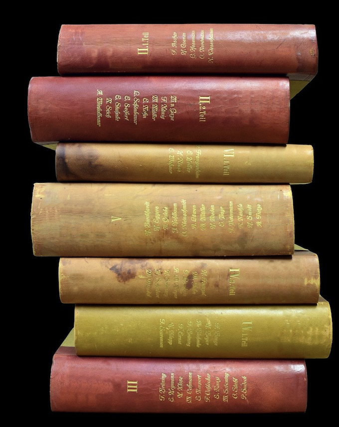

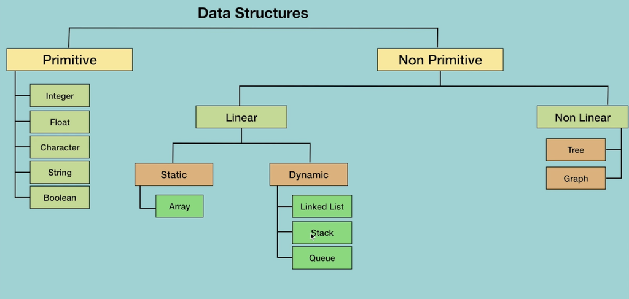

### Stacks

- Recall the stack of newspapers?
- Used to implement a last-in first-out (LIFO) type protocol

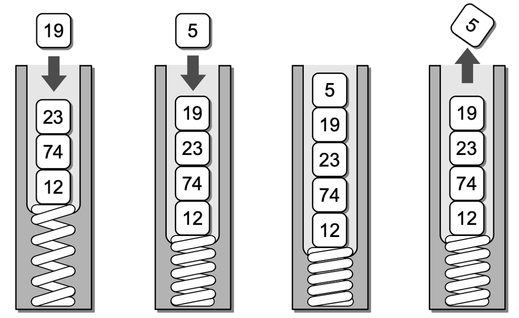

### Stack

- A stack is a linear data structure
- Access limited to a last-in first-out order.
- Adding and removing items is restricted to one end known as the top of the stack.
- An empty stack contains no items.

### Stack and operations

- $\tt Stack(\;)$ : Creates a new empty stack.
- $\tt isEmpty(\;)$ : Returns a boolean value indicating if the stack is empty.
- $\tt length(\;)$ : Returns the number of items in the stack.
- $\tt pop(\;)$ : Removes and returns the top item of the stack
  - if the stack is not empty.
  - items cannot be popped from an empty stack.
  - The next item on the stack becomes the new top item.

### Stack and operations...

- $\tt peek(\;)$ : Returns a reference to the item on top of a non-empty stack without removing it.
  - Peeking, which cannot be done on an empty stack, does not modify the stack contents.
- $\tt push(item)$ : Adds the given item to the top of the stack.

```python
# Implementation of the Stack ADT using a Python list.
class Stack :

    # Creates an empty stack.
    def __init__( self ):
        self._theItems = list()

    # Returns True if the stack is empty or False otherwise.
    def isEmpty( self ):
        return len( self ) == 0

    # Returns the number of items in the stack.
    def __len__ ( self ):
        return len( self._theItems )

    # Returns the top item on the stack without removing it.
    def peek( self ):
        assert not self.isEmpty(), "Cannot peek at an empty stack"
        return self._theItems[-1]

    # Removes and returns the top item on the stack.
    def pop( self ):
        assert not self.isEmpty(), "Cannot pop from an empty stack"
        return self._theItems.pop()

    # Push an item onto the top of the stack.
    def push( self, item ):
        self._theItems.append( item )
```

```python
mystack = Stack()

print(mystack.isEmpty())
mystack.push(21)
print(mystack.isEmpty())
mystack.push(43)
mystack.push(58)
print(mystack.__len__())
print("1:",mystack.peek())
print("popping:",mystack.pop())
print("2:",mystack.peek())
```

```
True
False
3
1: 58
popping: 58
2: 43
```

- $\tt isEmpty(\;)$ : $O(?)$
- $\tt length(\;)$ : $O(?)$
- $\tt pop(\;)$ : $O(?)$
- $\tt peek(\;)$ : $O(?)$
- $\tt push(item)$ : $O(?)$
- $\tt isEmpty(\;)$ : $O(1)$
- $\tt length(\;)$ : $O(1)$
- $\tt pop(\;)$ : $O(1)$
- $\tt peek(\;)$ : $O(1)$
- $\tt push(item)$ : $O(1)$

```python
# Implementation of the Stack ADT using a singly linked list.
class Stack :

    # Creates an empty stack.
    def __init__( self ):
        self._top = None
        self._size = 0

    # Returns True if the stack is empty or False otherwise.
    def isEmpty( self ):
        return self._top is None

    # Returns the number of items in the stack.
    def __len__( self ):
        return self._size

    # Returns the top item on the stack without removing it.
    def peek( self ):
        assert not self.isEmpty(), "Cannot peek at an empty stack"
        return self._top.item

    # Removes and returns the top item on the stack.
    def pop( self ):
        assert not self.isEmpty(), "Cannot pop from an empty stack"
        node = self._top
        self._top = self._top.next
        self._size -= 1
        return node.item

    # Pushes an item onto the top of the stack.
    def push( self, item ) :
        self._top = _StackNode( item, self._top )
        print("top is -->",item,self._top)
        self._size += 1

# The private storage class for creating stack nodes.
class _StackNode :
    def __init__( self, item, link ) :
        print(item,"points to:",link)
        self.item = item
        self.next = link
```

```python
myS = Stack()

myS.push(97)
myS.push(24)
myS.push(13)
print(myS.pop())
print(myS.peek())
```

```
97 points to: None
top is --> 97 <__main__._StackNode object at 0x7fa5d862a5b0>
24 points to: <__main__._StackNode object at 0x7fa5d862a5b0>
top is --> 24 <__main__._StackNode object at 0x7fa5d862a880>
13 points to: <__main__._StackNode object at 0x7fa5d862a880>
top is --> 13 <__main__._StackNode object at 0x7fa5d8630910>
13
24
```

```python
myS.push(24)
```

```
24 points to: <__main__._StackNode object at 0x7fa5d862a880>
top is --> 24 <__main__._StackNode object at 0x7fa5d8630e20>
```

#### Pop Operation

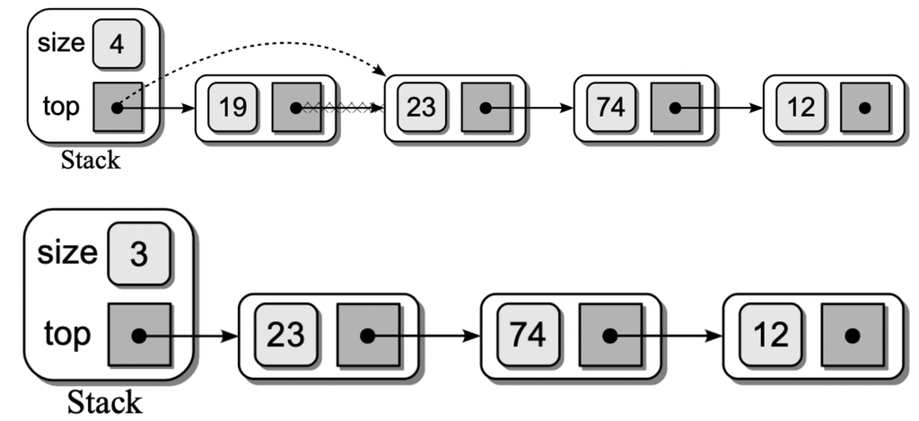

### Applications of Stacks - 1

- Balanced parenthesis ( ), brackets [ ], braces { }
- Basic Idea:
  - **push opening ones into a stack and pop them when you see matching closing ones.**
- For example,
  - "[ 1 + (3 - 5) ]"
    - push '[' into the stack
    - push '(' into the stack
    - when we see ')' , match and pop from the stack
    - when we see ']' , match and pop from the stack

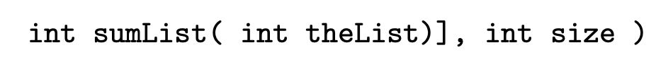

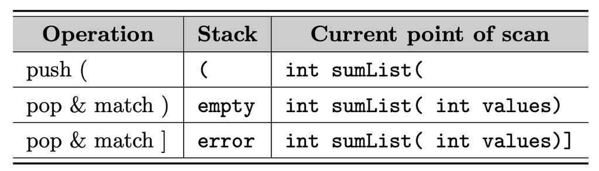

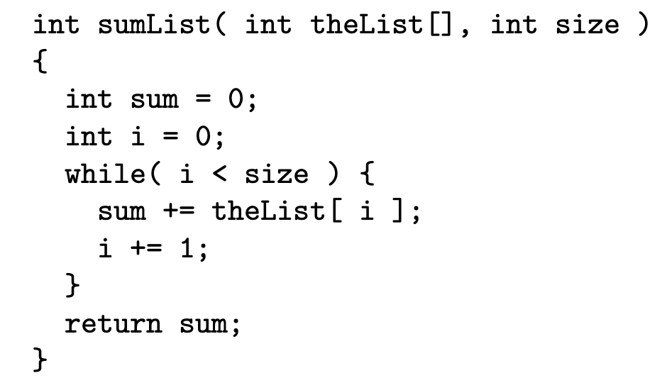

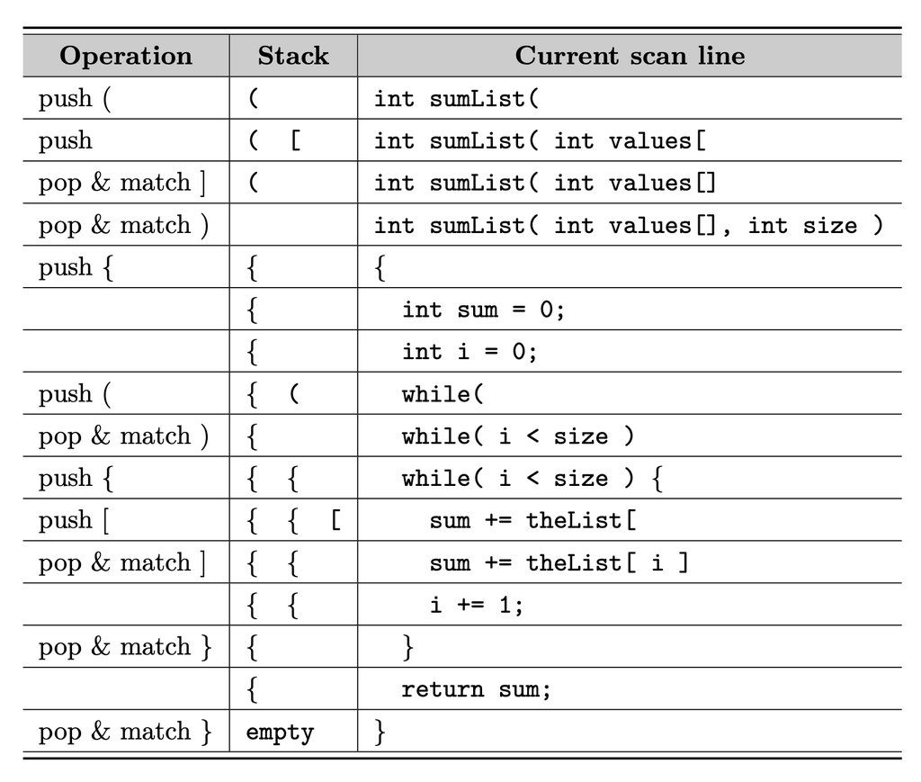

### Applications of Stacks - 2

- **Evaluating Postfix Expressions**
- Infix Expression: (A + B - C)
- Postfix Expression: AB+C-
  - (operand operand operator)
- Prefix Expression: -+ABC
  - (operator operand operand)

#### Postfix Expression: ABC+*D/

```
- (B + C)
- A * (B + C)
- (A * (B + C)) / D
```

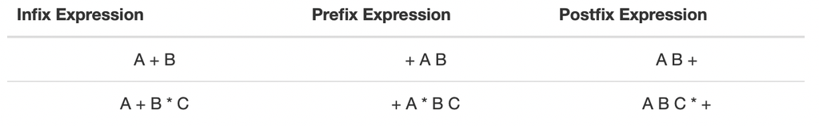

#### Example with parentheses

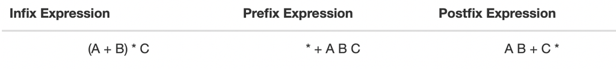

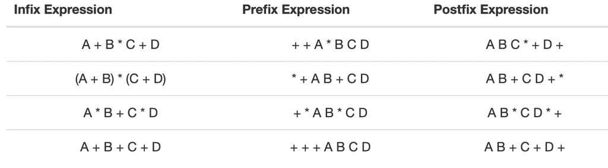

##### Note that the order of the operands never changes! :-)

#### Evaluating a postfix expression

A B C + * D /

A=8 C=3 B=2 D=4

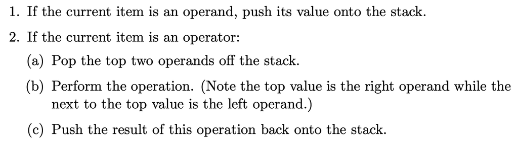

#### Evaluating a postfix expression

A B C + * D /

[figure not shown]

A=8 C=3 B=2 D=4

- Stack: 3 2 8 Looking at: +
  - (2 + 3)
- Stack: 5 8 Looking at: *
  - (8 * 5)
- Stack: 4 40 Looking at: /
  - (40 / 4)
- Stack: 10

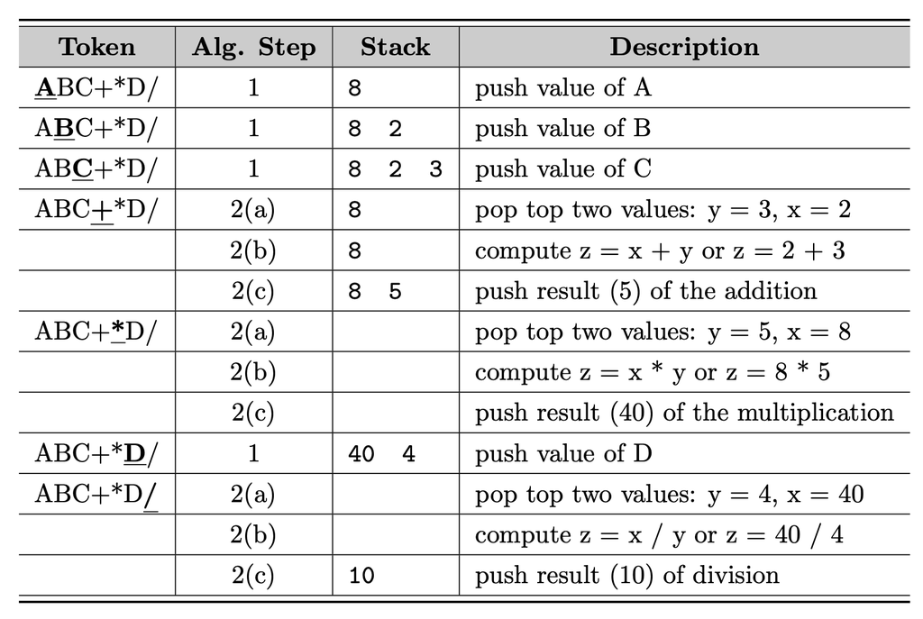

### Applications of Stacks - 3

- **Convert Infix Expressions to Postfix**

#### Convert Infix Expressions to Postfix

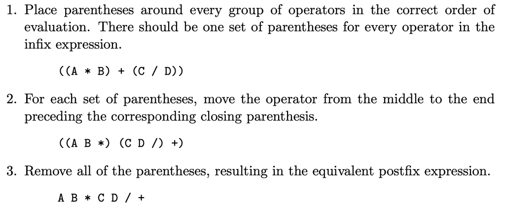

*Input*: A fully parenthesised infix expression

*Output*: The postfix equivalent

- If you see an operand, output it.
- If you see an operator, push it on the stack.
- If you see an opening parenthesis, push it on the stack.
- If you see a closing parenthesis, pop the operator and write it.

((A * B) + (C / D))

- Stack : ( ( *
- output: A B
- symbol: )

((A * B) + (C / D))

- Stack : (
- output: A B *
- Stack : ( + ( /
- output: A B * C D
- symbol: )

((A * B) + (C / D))

- Stack : ( +
- output: A B * C D /
- symbol: )
- Stack :
- output: A B * C D / +
- symbol:

```python
values = Stack()
for i in range( 17 ) :
    #print(i)
    if i % 3 == 0 :
        values.push( i )
        print(" - pushing",i)
    elif i % 4 == 0 :
        print(" - popping",values.pop())
```

```
 - pushing 0
 - pushing 3
 - popping 3
 - pushing 6
 - popping 6
 - pushing 9
 - pushing 12
 - pushing 15
 - popping 15
```